# R-code for ‘TITLE OF THE PAPER’

##### Plot PCA results grouped by secies

Visualising the PCA with species as a grouping variable shows considerable overlap, especially between *Buteo buteo* and *Milvus milvus*.

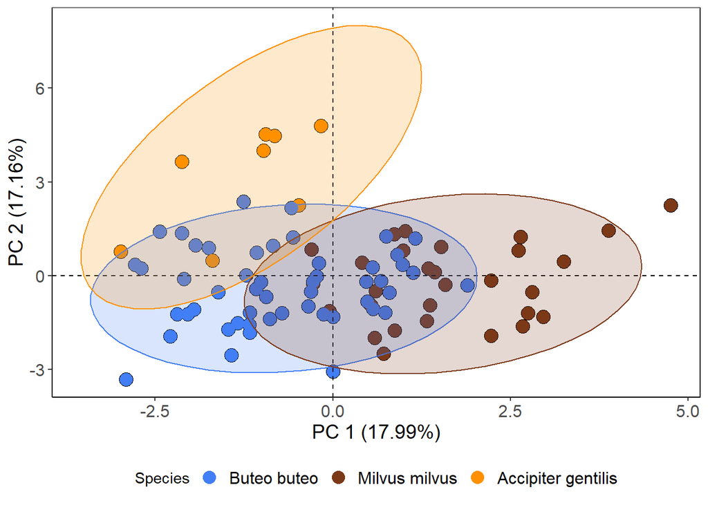

Fig 3. PCA using species as grouping factor

```r
spec.plot <-
  ggplot(pca.coords, aes(x = pc1, y = pc2, color = data$Species)) +
  geom_point(color = 'black', size = 4.5) +
  geom_point(size = 4) +
  labs(color = "Species") +
  xlab(paste0("PC 1 (", round(pca$eig[1,2],2),"%)"))+
  ylab(paste0("PC 2 (", round(pca$eig[2,2],2),"%)"))+
  geom_hline(yintercept = 0, lty = 2) +
  geom_vline(xintercept = 0, lty = 2) +
  scale_color_manual(values=c("#427EF6", "#7C3918", "#FF9100")) +
  scale_fill_manual(values=c("#427EF6", "#7C3918", "#FF9100")) +
  theme_classic()+
  theme(legend.position = "bottom",
        legend.text = element_text(size = 12),
        axis.title = element_text(size = 14),
        axis.text = element_text(size = 12),
        plot.title = element_text(hjust = 0.5, face = "bold"),
        panel.border = element_rect(fill = "transparent")) +
    stat_ellipse(geom = "polygon", aes(fill = data$Species),
                 alpha = 0.2, show.legend = FALSE, level = 0.95)
spec.plot
```

##### Plot PCA results grouped by infection intensity

Plotting PCA results grouped by infection intenstiy pooled for all three species shows considerable overlap between groups.

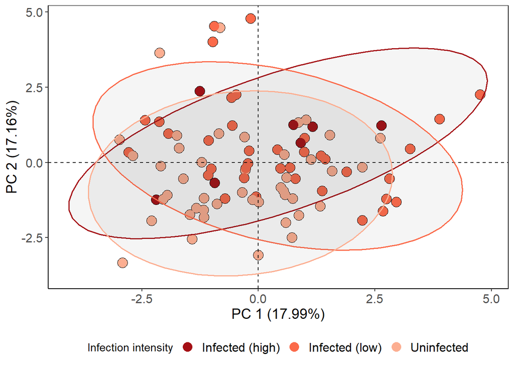

Fig 4. PCA using infection intensity as grouping factor

```r
inf.plot <- ggplot(data = pca.coords,
                     aes(x = pc1, y = pc2, color = as.factor(data$Infectionclass))) +
  geom_point(color='black',size=4.5) +
  geom_point(size = 4) +
  xlab(paste0("PC 1 (", round(pca$eig[1,2],2),"%)"))+
  ylab(paste0("PC 2 (", round(pca$eig[2,2],2),"%)"))+
  labs(color = "Infection intensity") +
  geom_hline(yintercept = 0, lty = 2) +
  geom_vline(xintercept = 0, lty = 2) +
  scale_color_manual(values = c("#A50F15","#FB6A4A","#FCAE91")) +
  scale_fill_manual(values = c("#A50F15","#FB6A4A","#FCAE91")) +
#  scale_fill_manual(values=c("#427EF6", "#7C3918", "#FF9100")) +
  theme_classic() +
  theme(legend.position = "bottom",
        legend.text = element_text(size = 12),
        axis.title = element_text(size = 14),
        axis.text = element_text(size = 12),
        plot.title = element_text(hjust = 0.5, face="bold"),
        panel.border = element_rect(fill= "transparent")) +
  stat_ellipse(geom ="polygon", aes(color = as.factor(data$Infectionclass)),
               alpha = 0.05, show.legend = FALSE, level = 0.95, size=0.7)

inf.plot
```

```r
#spec.plot/inf.plot|vars.p + plot_layout(ncol = 1)
```

#### B.) LDA

Linear discriminant analysis as supervised clustering method.

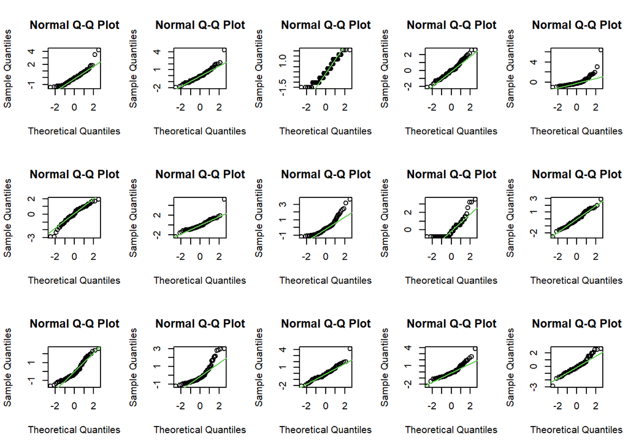

Fig 5. Q-Q plots of all numeric variables

```r
# Checking normal multivariate distribution
par(mfrow = c(3, 5))
for(i in dimnames(pca.dat)[[2]]) {
  qqnorm(pca.dat[,i]); qqline(pca.dat[,i], col = 3)
}
```

```r
# Checking homogeneity of the matrix variance - covariance
anova(betadisper(dist(pca.dat),data$Species))
```

```
## Analysis of Variance Table
##
## Response: Distances
##           Df Sum Sq Mean Sq F value Pr(>F)
## Groups     2  1.974 0.98692  0.8916 0.4138
## Residuals 85 94.085 1.10688
```

```r
# LDA constrained by species
(ldaSpecies=lda(pca.dat, data$Species))
```

```
## Call:
## lda(pca.dat, grouping = data$Species)
##
## Prior probabilities of groups:
##        Buteo buteo      Milvus milvus Accipiter gentilis
##         0.57954545         0.32954545         0.09090909
##
## Group means:
##                    Leukocyte_count Lymphocytes_percent Monocytes_percent
## Buteo buteo             -0.2256576           0.1231234        -0.2079110
## Milvus milvus            0.4792437          -0.2022596         0.6509771
## Accipiter gentilis      -0.2986911          -0.0517205        -1.0343596
##                    Heterophiles_percent  H_L_ratio Eosinophiles_percent
## Buteo buteo                  -0.2436137 -0.1980922            0.1341454
## Milvus milvus                 0.5076038  0.3936482           -0.3756042
## Accipiter gentilis           -0.2870261 -0.1641372            0.5063886
##                               AP        AST         gGT        CHE         BA
## Buteo buteo        -0.0001713819 -0.4171102 -0.08471284  0.3468685 -0.2558214
## Milvus milvus      -0.3333301138  0.3291056  0.09422974 -0.8294955  0.5085020
## Accipiter gentilis  1.2094142221  1.4660699  0.19846152  0.7956346 -0.2124584
##                           LDH         CK        ALB         TP
## Buteo buteo        -0.1020455  0.2584889 -0.3370631 -0.3679092
## Milvus milvus      -0.3234785 -0.6905027  0.3639083  0.3697216
## Accipiter gentilis  1.8231494  0.8552057  0.8296096  1.0051805
##
## Coefficients of linear discriminants:
##                              LD1         LD2
## Leukocyte_count       0.10405672  0.06734159
## Lymphocytes_percent   1.95140100 -5.78678385
## Monocytes_percent     0.78543495 -1.36383969
## Heterophiles_percent  1.94044480 -5.26088599
## H_L_ratio             0.12807699  0.06601741
## Eosinophiles_percent  1.84033762 -5.82506234
## AP                   -0.09498698  0.49281905
## AST                   0.84476064  0.72232175
## gGT                  -0.11753311  0.08084637
## CHE                  -0.99827520 -0.04789559
## BA                    0.49316041  0.04141142
## LDH                  -0.73281035  0.33878841
## CK                   -0.17091772 -0.10795256
## ALB                  -0.11976793  0.25197268
## TP                    0.39708811  0.13357234
##
## Proportion of trace:
##    LD1    LD2
## 0.7685 0.2315
```

```r
# Cross-validation of the dataset
# tableclass=base::table(bloody$Species, ldaSpecies$lass)
MVA.cv(pca.dat, data$Species, model = "LDA", scale=T)
```

[output not shown]

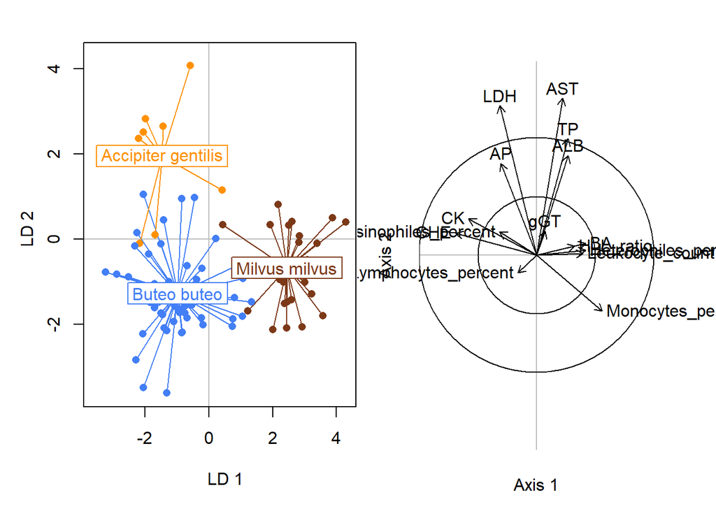

Fig 6. LDA visualised by species

```r
par(mfrow = c(1,2))
MVA.plot(ldaSpecies, fac = data$Species, xlab = "LD 1", ylab = "LD 2",
         col = c("#427EF6", "#7C3918", "#FF9100"), legend = F, legend.cex = 0.5,
         legend.pos = "topleft",
         legend.lab = c("Accipiter gentilis", "Buteo buteo","Milvus milvus"))
MVA.plot(ldaSpecies, "corr", xlab = "Axis 1", ylab = "Axis 2")
```

##### LDA constrained by Infection class

```r
# Checking for homogeneity within the variance-covariance matrix (equivalent of homoscedasticity of univariate test)
anova(betadisper(dist(pca.dat),data$Infectionclass))
```

```
## Analysis of Variance Table
##
## Response: Distances
##           Df  Sum Sq Mean Sq F value Pr(>F)
## Groups     2   4.057  2.0287   1.354 0.2637
## Residuals 85 127.355  1.4983
```

```r
anova(betadisper(dist(pca.dat),data$Infection_binomial))
```

```
## Analysis of Variance Table
##
## Response: Distances
##           Df Sum Sq Mean Sq F value Pr(>F)
## Groups     1   1.41  1.4104  0.9254 0.3388
## Residuals 86 131.07  1.5241
```

```r
ldaInfclass = lda(pca.dat, data$Infectionclass)   #  CV=T
ldaInfclass = lda(pca.dat, data$Infection_binomial)   #  CV=T

# Infection (0/1) in the three species

MVA.cv(pca.dat, data$Infection_binomial, model="LDA", scale=T)
```

```
##
##         Cross validation
##
## Model: LDA
## 7-fold validation
## Validation repeated 10 times
## 70 submodels generated (1 components)
##
## Classification criterion: plug-in
##
## Mean (standard error) classification error rate (%): 29.9 (0.61)
```

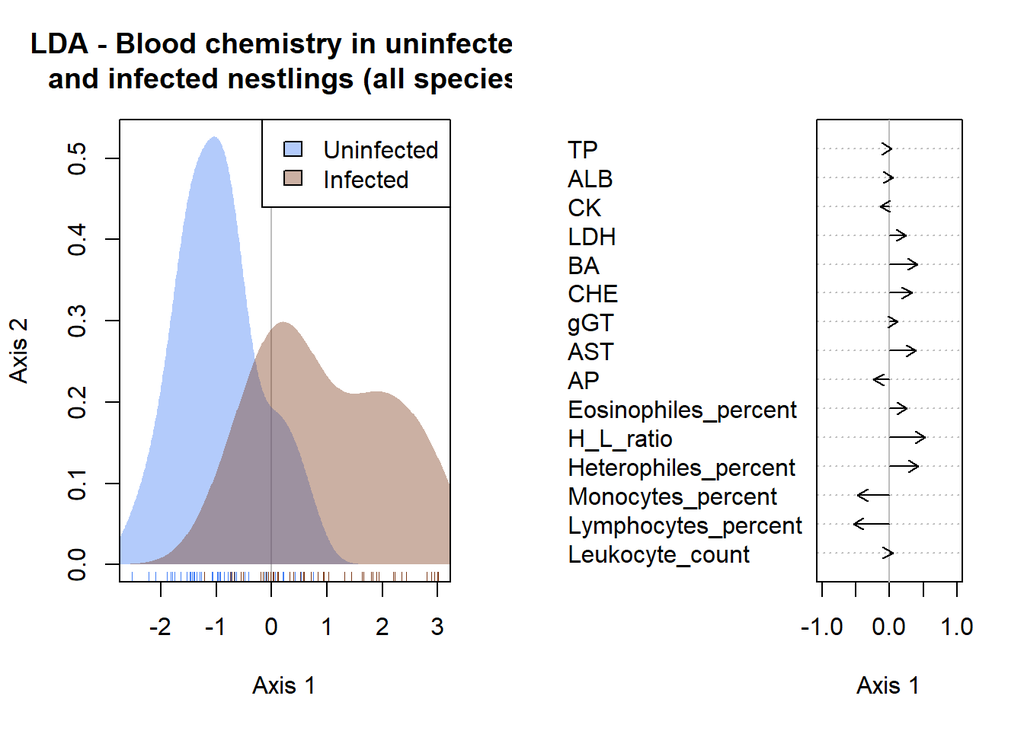

Fig 7. LDA with prevelance as response. All speices pooled

```r
par(mfrow = c(1,2))
MVA.plot(ldaInfclass, fac = data$Infection_binomial,
         xlab = "Axis 1",
         ylab = "Axis 2",
         main="LDA - Blood chemistry in uninfected \n and infected nestlings (all species)",
         col = c("#427EF6", "#7C3918"),
         legend = T,
         legend.cex = 0.9,
         legend.pos = "topright",
         legend.lab = c("Uninfected", "Infected")) # need to adjust the size of the box

MVA.plot(ldaInfclass,"corr", xlab = "Axis 1", ylab = "Axis 2")
```

```r
# Infection (0/1) in Buteo buteo

buteo <- which(data$Species == "Buteo buteo")

MVA.cv(pca.dat[buteo,], data$Infection_binomial[buteo], model="LDA", scale=T)
```

```
##
##         Cross validation
##
## Model: LDA
## 7-fold validation
## Validation repeated 10 times
## 70 submodels generated (1 components)
##
## Classification criterion: plug-in
##
## Mean (standard error) classification error rate (%): 76.1 (1.1)
```

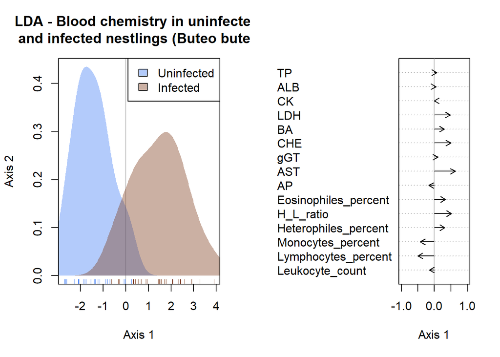

Fig 8. LDA with prevelance as response. Buteo buteo only

```r
ldaInfclass_buteo = lda(pca.dat[buteo,], data$Infection_binomial[buteo])   #  CV=T

par(mfrow = c(1,2))
MVA.plot(ldaInfclass_buteo, fac = data$Infection_binomial[buteo],
         xlab = "Axis 1",
         ylab = "Axis 2",
         main="LDA - Blood chemistry in uninfected \n and infected nestlings (Buteo buteo)",
         col = c("#427EF6", "#7C3918"),# "#FF9100"),
         legend = T,
         legend.cex = 0.9,
         legend.pos = "topright",
         legend.lab = c("Uninfected", "Infected"))
MVA.plot(ldaInfclass_buteo,"corr", xlab = "Axis 1", ylab = "Axis 2")
```

```r
# Infection (0/1) in Accipiter gentilis

Agentilis <- which(data$Species == "Accipiter gentilis")

MVA.cv(pca.dat[Agentilis,], data$Infection_binomial[Agentilis], model="LDA", scale=T)
```

```
##
##         Cross validation
##
## Model: LDA
## 4-fold validation
## Validation repeated 10 times
## 40 submodels generated (1 components)
##
## Classification criterion: plug-in
##
## Mean (standard error) classification error rate (%): 25 (3.7)
```

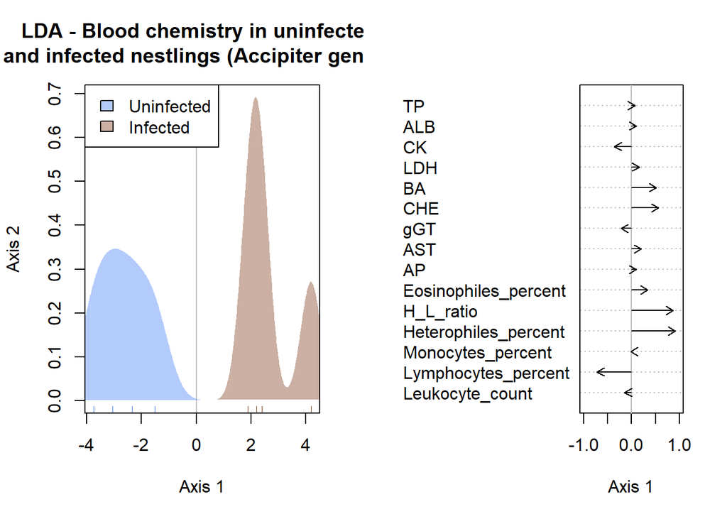

Fig 9. LDA with prevelance as response. Accipiter gentilis only

```r
ldaInfclass_agentilis = lda(pca.dat[Agentilis,], data$Infection_binomial[Agentilis])   #  CV=T

par(mfrow = c(1,2))
MVA.plot(ldaInfclass_agentilis, fac = data$Infection_binomial[Agentilis],
         main="LDA - Blood chemistry in uninfected \n and infected nestlings (Accipiter gentilis)",
         xlab = "Axis 1",
         ylab = "Axis 2",
         col = c("#427EF6", "#7C3918"),# "#FF9100"),
         legend = T,
         legend.cex = 0.9,
         legend.pos = "topleft",
         legend.lab = c("Uninfected", "Infected"))
MVA.plot(ldaInfclass_agentilis,"corr", xlab = "Axis 1", ylab = "Axis 2")
```

```r
# Infection (0/1) in Milvus milvus

milvus <- which(data$Species == "Milvus milvus")

MVA.cv(pca.dat[milvus,], data$Infection_binomial[milvus], model="LDA", scale=T)
```

```
##
##         Cross validation
##
## Model: LDA
## 7-fold validation
## Validation repeated 10 times
## 70 submodels generated (1 components)
##
## Classification criterion: plug-in
##
## Mean (standard error) classification error rate (%): 34.1 (1.7)
```

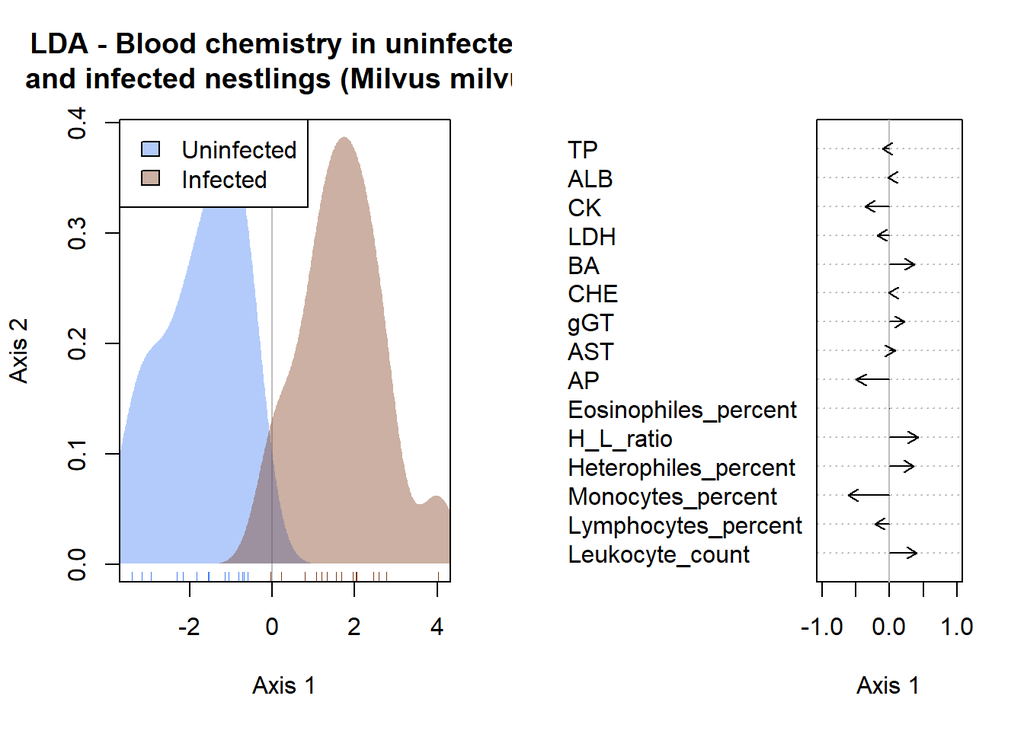

Fig 10. LDA with prevelance as response. Milvus milvus only

```r
ldaInfclass_milvus = lda(pca.dat[milvus,], data$Infection_binomial[milvus])   #  CV=T

par(mfrow = c(1,2))
MVA.plot(ldaInfclass_milvus, fac = data$Infection_binomial[milvus],
         main="LDA - Blood chemistry in uninfected \n and infected nestlings (Milvus milvus)",
         xlab = "Axis 1",
         ylab = "Axis 2",
         col = c("#427EF6", "#7C3918"),# "#FF9100"),
         legend = T,
         legend.cex = 0.9,
         legend.pos = "topleft",
         legend.lab = c("Uninfected", "Infected"))

         #legend.lab = c("High Infection", "Low Infection","No Infection"))
MVA.plot(ldaInfclass_milvus,"corr", xlab = "Axis 1", ylab = "Axis 2")
```

##### LDA constrained by Age classes Three weeks / A month / A month+

*Only explorative*

```r
anova(betadisper(dist(pca.dat),data$AgeClass))
```

```
## Analysis of Variance Table
##
## Response: Distances
##           Df  Sum Sq Mean Sq F value  Pr(>F)
## Groups     2   8.321  4.1606  3.0367 0.05323 .
## Residuals 85 116.458  1.3701
## ---
## Signif. codes:  0 '***' 0.001 '**' 0.01 '*' 0.05 '.' 0.1 ' ' 1
```

```r
ldaAge=lda(pca.dat, data$AgeClass)   #  CV=T

MVA.cv(pca.dat, data$AgeClass,model="LDA", scale=T)
```

```
##
##         Cross validation
##
## Model: LDA
## 7-fold validation
## Validation repeated 10 times
## 70 submodels generated (2 components)
##
## Classification criterion: plug-in
##
## Mean (standard error) classification error rate (%): 40.6 (0.78)
```

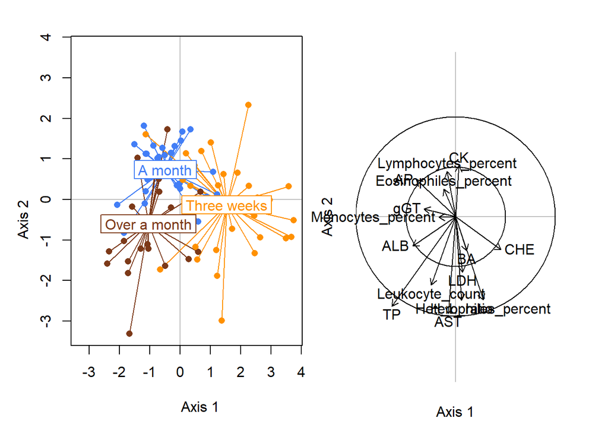

```r
par(mfrow=c(1,2))
MVA.plot(ldaAge, fac = data$AgeClass,
         xlab = "Axis 1", ylab = "Axis 2",
         col=c("#427EF6", "#7C3918", "#FF9100"),
         legend=F, legend.cex=0.9, legend.pos="topleft")
MVA.plot(ldaAge,"corr", xlab="Axis 1", ylab="Axis 2")
```

##### LDA constrained by Age classes first, second and third third of their nestling period

*Only explorative*

```r
anova(betadisper(dist(pca.dat),data$AgeClass2))
```

```
## Analysis of Variance Table
##
## Response: Distances
##           Df  Sum Sq Mean Sq F value   Pr(>F)
## Groups     2  16.814  8.4068  6.1471 0.003211 **
## Residuals 85 116.247  1.3676
## ---
## Signif. codes:  0 '***' 0.001 '**' 0.01 '*' 0.05 '.' 0.1 ' ' 1
```

```r
ldaAge=lda(pca.dat, data$AgeClass2)   #  CV=T

MVA.cv(pca.dat, data$Infectionclass,model="LDA", scale=T)
```

```
##
##         Cross validation
##
## Model: LDA
## 7-fold validation
## Validation repeated 10 times
## 70 submodels generated (2 components)
##
## Classification criterion: plug-in
##
## Mean (standard error) classification error rate (%): 76.6 (0.7)
```

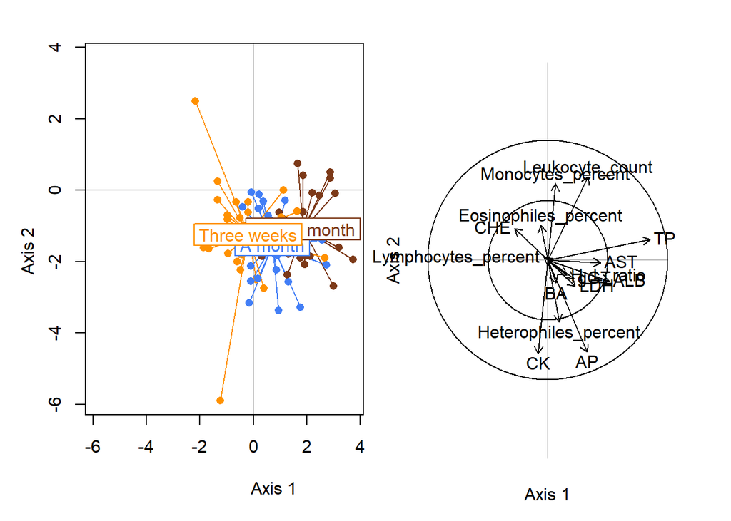

```r
par(mfrow=c(1,2))
MVA.plot(ldaAge, fac = data$AgeClass,
         xlab = "Axis 1", ylab = "Axis 2",
         col=c("#427EF6", "#7C3918", "#FF9100"),
         legend=F, legend.cex=0.9, legend.pos="topleft")
MVA.plot(ldaAge,"corr", xlab="Axis 1", ylab="Axis 2")
```

#### C.) Linear models

*In all linear models, infection status is represented as a factor with two levels (Infected vs Uninfected) to balance sample sizes*

##### Test 1: *Heterophiles are significantly higher in infected individuals across species*

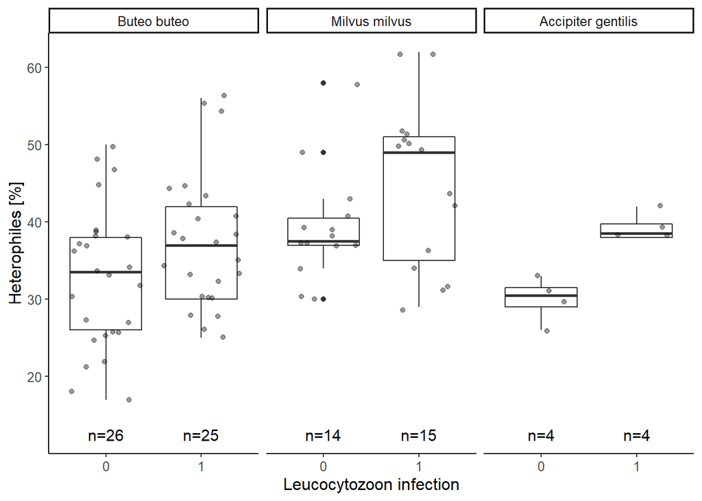

```r
heterophiles_plot <- ggplot(data, aes(x = as.factor(Infection_binomial), y = Heterophiles_percent)) +
  geom_boxplot() +
  geom_jitter(alpha = 0.4) +
  theme_classic() +
  theme(text = element_text(size = 12),
        panel.border = element_blank(),
        plot.margin = grid::unit(c(2,2,2,2), 'mm')) +
  ylab("Heterophiles [%]") +
  xlab("Leucocytozoon infection") +
  stat_n_text() +
  facet_wrap(~Species)
heterophiles_plot
```

```r
model <- lm(Heterophiles_percent ~ Infection_binomial + Sex + Age + Species, data)
tab_model(model,
          show.stat = T,
          string.est = "Estimate",
          string.ci = "95% CI",
          string.stat = "z",
          string.se = "SE",
          show.se = T,
          transform = NULL,
          collapse.ci = T)
```

|  | Heterophiles_percent |  |  |  |
| --- | --- | --- | --- | --- |
| Predictors | Estimate | SE | z | p |
| (Intercept) | 32.14 (28.57 – 35.71) | 1.80 | 17.90 | **<0.001** |
| Infection_binomial [1] | 4.42 (0.82 – 8.01) | 1.81 | 2.44 | **0.017** |
| Sex [Male] | -0.47 (-4.04 – 3.10) | 1.79 | -0.26 | 0.794 |
| Age | -2.93 (-4.91 – -0.94) | 1.00 | -2.93 | **0.004** |
| Species [Milvus milvus] | 9.31 (5.16 – 13.47) | 2.09 | 4.46 | **<0.001** |
| Species [Accipiter gentilis] | 2.21 (-4.37 – 8.80) | 3.31 | 0.67 | 0.506 |
| Observations | 88 |  |  |  |
| R<sup>2</sup> / R<sup>2</sup> adjusted | 0.287 / 0.243 |  |  |  |

[output not shown]

##### Test 2: *Lymphocytes are significantly lower in infected individuals across species*

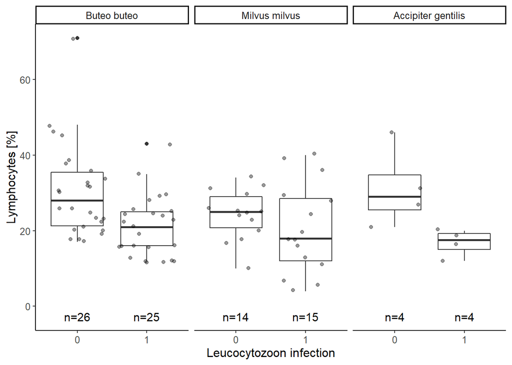

```r
lymphocytes_plot <- ggplot(data,
                            aes(x = as.factor(Infection_binomial), y = Lymphocytes_percent)) +
  geom_boxplot() +
  geom_jitter(alpha = 0.4) +
  theme_classic() +
  theme(text = element_text(size = 12),
        panel.border = element_blank(),
        #strip.background = element_rect(fill = "white", colour = "white"),
        #strip.text = element_text(colour = 'white'),
        plot.margin = grid::unit(c(2,2,2,2), 'mm')) +
  ylab("Lymphocytes [%]") +
  xlab("Leucocytozoon infection") +
  stat_n_text() +
  facet_wrap(~Species)
lymphocytes_plot
```

```r
model <- lm(Lymphocytes_percent ~ Infection_binomial + Sex + Age + Species, data)
tab_model(model,
          show.stat = T,
          string.est = "Estimate",
          string.ci = "95% CI",
          string.stat = "z",
          string.se = "SE",
          show.se = T,
          transform = NULL,
          collapse.ci = T)
```

|  | Lymphocytes_percent |  |  |  |
| --- | --- | --- | --- | --- |
| Predictors | Estimate | SE | z | p |
| (Intercept) | 31.52 (27.20 – 35.83) | 2.17 | 14.51 | **<0.001** |
| Infection_binomial [1] | -7.91 (-12.26 – -3.57) | 2.19 | -3.62 | **0.001** |
| Sex [Male] | -2.86 (-7.18 – 1.46) | 2.17 | -1.32 | 0.191 |
| Age | 0.20 (-2.20 – 2.60) | 1.21 | 0.17 | 0.866 |
| Species [Milvus milvus] | -3.65 (-8.68 – 1.37) | 2.53 | -1.45 | 0.152 |
| Species [Accipiter gentilis] | -2.61 (-10.58 – 5.36) | 4.01 | -0.65 | 0.517 |
| Observations | 88 |  |  |  |
| R<sup>2</sup> / R<sup>2</sup> adjusted | 0.180 / 0.130 |  |  |  |

##### Test 3: *BA is significantly higher in infected individuals across species*

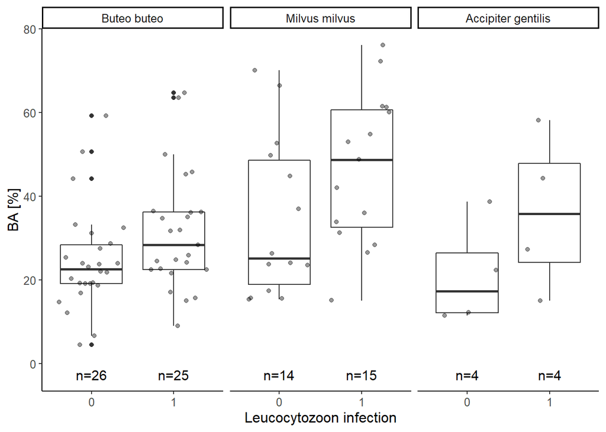

```r
BA_plot <- ggplot(data, aes(x = as.factor(Infection_binomial), y = BA)) +
  geom_boxplot() +
  geom_jitter(alpha = 0.4) +
  theme_classic() +
  theme(text = element_text(size = 12),
        panel.border = element_blank(),
        #strip.background = element_rect(fill = "white", colour = "white"),
        #strip.text = element_text(colour = 'white'),
        plot.margin = grid::unit(c(2,2,2,2), 'mm')) +
  ylab("BA [%]") +
  xlab("Leucocytozoon infection") +
  stat_n_text() +
  facet_wrap(~Species)
BA_plot
```

```r
model <- lm(BA ~ Infection_binomial + Sex + Age + Species, data)
tab_model(model,
          show.stat = T,
          string.est = "Estimate",
          string.ci = "95% CI",
          string.stat = "z",
          string.se = "SE",
          show.se = T,
          transform = NULL,
          collapse.ci = T)
```

|  | BA |  |  |  |
| --- | --- | --- | --- | --- |
| Predictors | Estimate | SE | z | p |
| (Intercept) | 20.65 (14.16 – 27.14) | 3.26 | 6.33 | **<0.001** |
| Infection_binomial [1] | 8.44 (1.91 – 14.97) | 3.28 | 2.57 | **0.012** |
| Sex [Male] | 4.08 (-2.41 – 10.57) | 3.26 | 1.25 | 0.215 |
| Age | -2.34 (-5.94 – 1.27) | 1.81 | -1.29 | 0.201 |
| Species [Milvus milvus] | 14.72 (7.17 – 22.27) | 3.80 | 3.88 | **<0.001** |
| Species [Accipiter gentilis] | 3.73 (-8.24 – 15.70) | 6.02 | 0.62 | 0.537 |
| Observations | 88 |  |  |  |
| R<sup>2</sup> / R<sup>2</sup> adjusted | 0.238 / 0.192 |  |  |  |